# My R Markdown Document

1434453

2023-12-08

```r
options(repos = c(CRAN = "https://cloud.r-project.org/"))
install.packages("ggplot2")
install.packages("palmerpenguins")
install.packages("janitor")
install.packages("dplyr")
install.packages("tinytex")
library("ggplot2")
library("palmerpenguins")
library("janitor")
library("dplyr")
library("tinytex")
head(penguins_raw)
```

```
## # A tibble: 6 × 17
##   studyName `Sample Number` Species          Region Island Stage `Individual ID`
##   <chr>               <dbl> <chr>            <chr>  <chr>  <chr> <chr>
## 1 PAL0708                 1 Adelie Penguin … Anvers Torge… Adul… N1A1
## 2 PAL0708                 2 Adelie Penguin … Anvers Torge… Adul… N1A2
## 3 PAL0708                 3 Adelie Penguin … Anvers Torge… Adul… N2A1
## 4 PAL0708                 4 Adelie Penguin … Anvers Torge… Adul… N2A2
## 5 PAL0708                 5 Adelie Penguin … Anvers Torge… Adul… N3A1
## 6 PAL0708                 6 Adelie Penguin … Anvers Torge… Adul… N3A2
## # ℹ 10 more variables: `Clutch Completion` <chr>, `Date Egg` <date>,
## #   `Culmen Length (mm)` <dbl>, `Culmen Depth (mm)` <dbl>,
## #   `Flipper Length (mm)` <dbl>, `Body Mass (g)` <dbl>, Sex <chr>,
## #   `Delta 15 N (o/oo)` <dbl>, `Delta 13 C (o/oo)` <dbl>, Comments <chr>
```

*The following is a template .rmd RMarkdown file for you to use for your homework submission.*

*Please Knit your .rmd to a PDF format or HTML and submit that with no identifiers like your name.*

*To create a PDF, first install tinytex and load the package. Then press the Knit arrow and select “Knit to PDF”.*

## QUESTION 01: Data Visualisation for Science Communication

*Create a figure using the Palmer Penguin dataset that is correct but badly communicates the data. **Do not make a boxplot**.*

*Use the following references to guide you:*

- [*https://www.nature.com/articles/533452a*](https://www.nature.com/articles/533452a)
- [*https://elifesciences.org/articles/16800*](https://elifesciences.org/articles/16800)

*Note: Focus on visual elements rather than writing misleading text on it.*

### a) Provide your figure here:

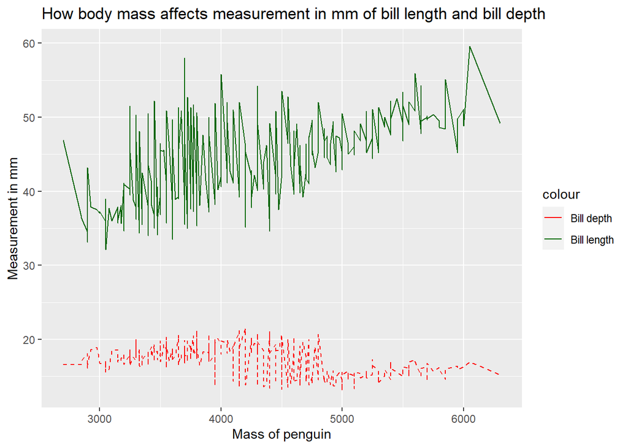

### b) Write about how your design choices mislead the reader about the underlying data (200-300 words).

This graph is misleading as it includes a lot of data is on the graph as it has two y variables being used on the same y axis. This would confuse or mislead a viewer as it is a lot of information to pay attention to. Also as there is two y variables and they are not close in values, it means that the values for bill depth are hard to see as they are made very small to fit in the values for bill length. The points all joined by a line which does not give an indication of any correlation - whether this is positive or negative. Also by not displaying the individual data points you cannot see the spread of the data. The colours are inappropriate as might not be accessible for any people with colour blindness.Also the dashed line makes it harder to see the values for bill depth. Bill length on the bottom of the key but at the top of the figure this would make this more confusing as you would need to pay attention to the colours and the key is in an illogical order.

*Include references.*

## QUESTION 2: Data Pipeline

*Write a data analysis pipeline in your .rmd RMarkdown file. You should be aiming to write a clear explanation of the steps as well as clear code.*

*Your code should include the steps practiced in the lab session:*

- *Load the data*
- *Appropriately clean the data*
- *Create an Exploratory Figure (**not a boxplot**)*
- *Save the figure*
- **New**: Run a statistical test
- **New**: Create a Results Figure
- *Save the figure*

*An exploratory figure shows raw data, such as the distribution of the data. A results figure demonstrates the stats method chosen, and includes the results of the stats test.*

*Between your code, communicate clearly what you are doing and why.*

*Your text should include:*

- *Introduction*
- *Hypothesis*
- *Stats Method*
- *Results*
- *Discussion*
- *Conclusion*

*You will be marked on the following:*

### a) Your code for readability and functionality

### b) Your figures for communication

### c) Your text communication of your analysis

*Below is a template you can use.*

### Introduction

- *Load the data*
- *Appropriately clean the data*
- *Create an Exploratory Figure (**not a boxplot**)*
- *Save the figure*

```r
#install.packages(c("ggplot2", "palmerpenguins", "janitor", "dplyr"))

library(ggplot2)
library(palmerpenguins)
library(janitor)
library(dplyr)
library(ragg)
head(penguins_raw)
```

```
## # A tibble: 6 × 17
##   studyName `Sample Number` Species          Region Island Stage `Individual ID`
##   <chr>               <dbl> <chr>            <chr>  <chr>  <chr> <chr>
## 1 PAL0708                 1 Adelie Penguin … Anvers Torge… Adul… N1A1
## 2 PAL0708                 2 Adelie Penguin … Anvers Torge… Adul… N1A2
## 3 PAL0708                 3 Adelie Penguin … Anvers Torge… Adul… N2A1
## 4 PAL0708                 4 Adelie Penguin … Anvers Torge… Adul… N2A2
## 5 PAL0708                 5 Adelie Penguin … Anvers Torge… Adul… N3A1
## 6 PAL0708                 6 Adelie Penguin … Anvers Torge… Adul… N3A2
## # ℹ 10 more variables: `Clutch Completion` <chr>, `Date Egg` <date>,
## #   `Culmen Length (mm)` <dbl>, `Culmen Depth (mm)` <dbl>,
## #   `Flipper Length (mm)` <dbl>, `Body Mass (g)` <dbl>, Sex <chr>,
## #   `Delta 15 N (o/oo)` <dbl>, `Delta 13 C (o/oo)` <dbl>, Comments <chr>
```

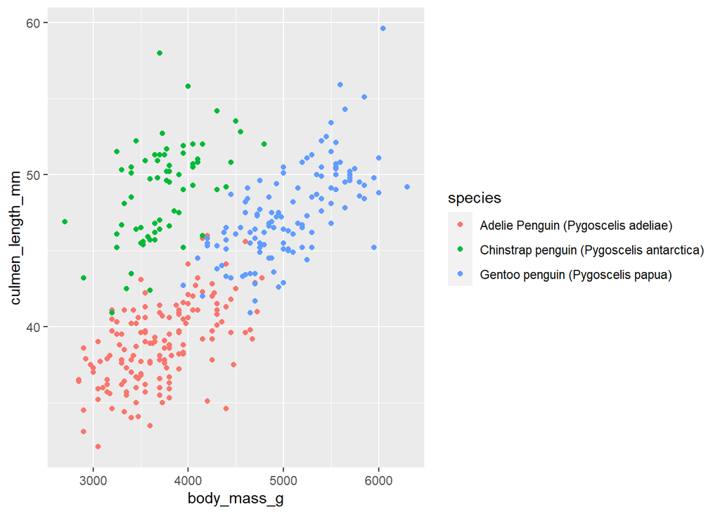

```r
#loading data

write.csv(penguins_raw, "data/penguins_raw.csv")

source("functions/cleaning.r")
penguins_clean <- penguins_raw %>%
    clean_column_names() %>%
    shorten_species() %>%
    remove_empty_columns_rows()
penguins_clean <- clean_function(penguins_raw)
penguins_clean <- as.data.frame(penguins_clean)

penguinexp <- ggplot(penguins_clean, aes(x = body_mass_g, y = culmen_length_mm, color = species)) +
  geom_point()
penguinexp
```

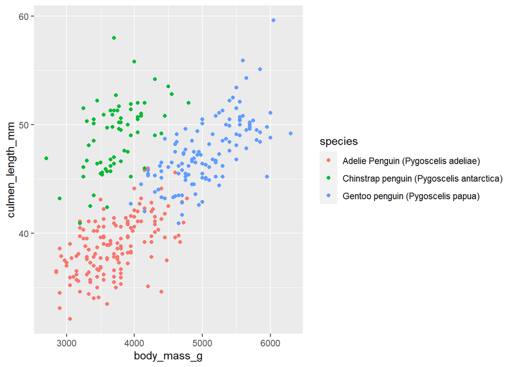

```r
source("functions/plotting.r")

penguinexplor <- plot_exploratory_figure(penguins_clean)
penguinexplor
```

```r
save_flipper_plot_png(penguins_clean,
                      "figures/fig01_penguinexp.png",
                      size = 15, res = 600, scaling=1)
```

```r
# Make sure your code prints.
```

First I have installed the packages needed to complete this analysis, these include ggplot (to form the graphs), palmerpenguins (this includes the data), janitor (provides functions that are needed to clean the data) and dplyr (gives functions that allow you to alter components of the data frame).

Then I checked whether the data frame I needed was properly installed by running the head() function which allows you to see the first few rows of the data frame and the column names.

Then I converted the penguin_raw data into a csv file.

For this analysis I have cleaned the code, meaning I have removed irrelevant columns such as comments from the data frame. The frame containing the function source() is to access the file that the functions I created are in, these functions include shorten_species. Doing this allows you to remove data that would impede the ability to make the graph and makes the data frame more readable.

I have then made exploratory graph depicting body mass (g) relationship to culmen length (mm) and colouring the different points by their species. This was then saved to a file called “figures”.

### Hypothesis

Alternative hypothesis or H1 is that penguin body mass increases as culmen length increases.And that this is different between species. The null hypothesis or H0 is that there is no relationship between penguin body mass and penguin culmen length, and that there is no difference between species.

### Statistical Methods

Here I create a model exploring the relationship between body mass, culmen length and species. I then check the assumptions of an ANCOVA analysis by doing a qqplot and plotting a residuals vs fitted plot. The qq plot tests for a normal distribution, which the data does have. The fitted vs residual plot tests for linearity.

Summary gives us estimates for the intercepts and slopes. As well, it gives us the p-values for these relationships so you can see if they’re significant. The function anova() completes an anova analysis on the model.

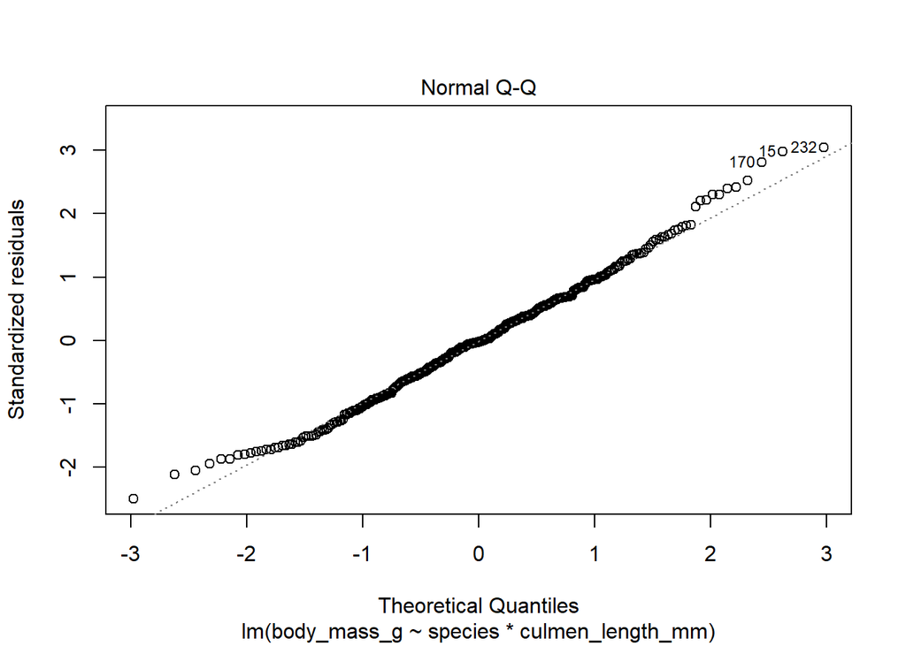

```r
pen_model <- lm(body_mass_g ~ species * culmen_length_mm, penguins_clean)

plot(pen_model, which = 2)
```

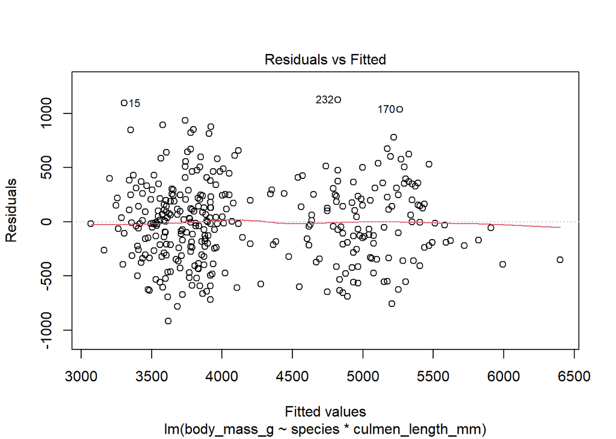

```r
plot(pen_model, which = 1)
```

```r
summary(pen_model)
```

```
##
## Call:
## lm(formula = body_mass_g ~ species * culmen_length_mm, data = penguins_clean)
##
## Residuals:
##     Min      1Q  Median      3Q     Max
## -918.76 -245.89   -8.65  238.44 1126.27
##
## Coefficients:
##                                                                   Estimate
## (Intercept)                                                          34.88
## speciesChinstrap penguin (Pygoscelis antarctica)                    811.26
## speciesGentoo penguin (Pygoscelis papua)                           -158.71
## culmen_length_mm                                                     94.50
## speciesChinstrap penguin (Pygoscelis antarctica):culmen_length_mm   -35.38
## speciesGentoo penguin (Pygoscelis papua):culmen_length_mm            14.96
##                                                                   Std. Error
## (Intercept)                                                           443.18
## speciesChinstrap penguin (Pygoscelis antarctica)                      799.81
## speciesGentoo penguin (Pygoscelis papua)                              683.19
## culmen_length_mm                                                       11.40
## speciesChinstrap penguin (Pygoscelis antarctica):culmen_length_mm      17.75
## speciesGentoo penguin (Pygoscelis papua):culmen_length_mm              15.79
##                                                                   t value
## (Intercept)                                                         0.079
## speciesChinstrap penguin (Pygoscelis antarctica)                    1.014
## speciesGentoo penguin (Pygoscelis papua)                           -0.232
## culmen_length_mm                                                    8.291
## speciesChinstrap penguin (Pygoscelis antarctica):culmen_length_mm  -1.994
## speciesGentoo penguin (Pygoscelis papua):culmen_length_mm           0.948
##                                                                   Pr(>|t|)
## (Intercept)                                                          0.937
## speciesChinstrap penguin (Pygoscelis antarctica)                     0.311
## speciesGentoo penguin (Pygoscelis papua)                             0.816
## culmen_length_mm                                                  2.73e-15 ***
## speciesChinstrap penguin (Pygoscelis antarctica):culmen_length_mm    0.047 *
## speciesGentoo penguin (Pygoscelis papua):culmen_length_mm            0.344
## ---
## Signif. codes:  0 '***' 0.001 '**' 0.01 '*' 0.05 '.' 0.1 ' ' 1
##
## Residual standard error: 371.8 on 336 degrees of freedom
##   (2 observations deleted due to missingness)
## Multiple R-squared:  0.7882, Adjusted R-squared:  0.7851
## F-statistic: 250.1 on 5 and 336 DF,  p-value: < 2.2e-16
```

```r
anova(pen_model)
```

```
## Analysis of Variance Table
##
## Response: body_mass_g
##                           Df    Sum Sq  Mean Sq F value  Pr(>F)
## species                    2 146864214 73432107  531.21 < 2e-16 ***
## culmen_length_mm           1  24829776 24829776  179.62 < 2e-16 ***
## species:culmen_length_mm   2   1166702   583351    4.22 0.01549 *
## Residuals                336  46447006   138235
## ---
## Signif. codes:  0 '***' 0.001 '**' 0.01 '*' 0.05 '.' 0.1 ' ' 1
```

```r
# Make sure your code prints.
```

The adjusted R-squared value obtained for this is 0.785, which suggests that 78.5% of the variation is explained by this model. Body masses relationship to species and culmen length are both significant as the p-value obtained was <2e-16. The p value is 0.01549 for the interaction between body mass, species and culmen length, this value is below 0.05 so the interaction is significant. The relationship between body mass and culmen length does differ between species.

### Results & Discussion

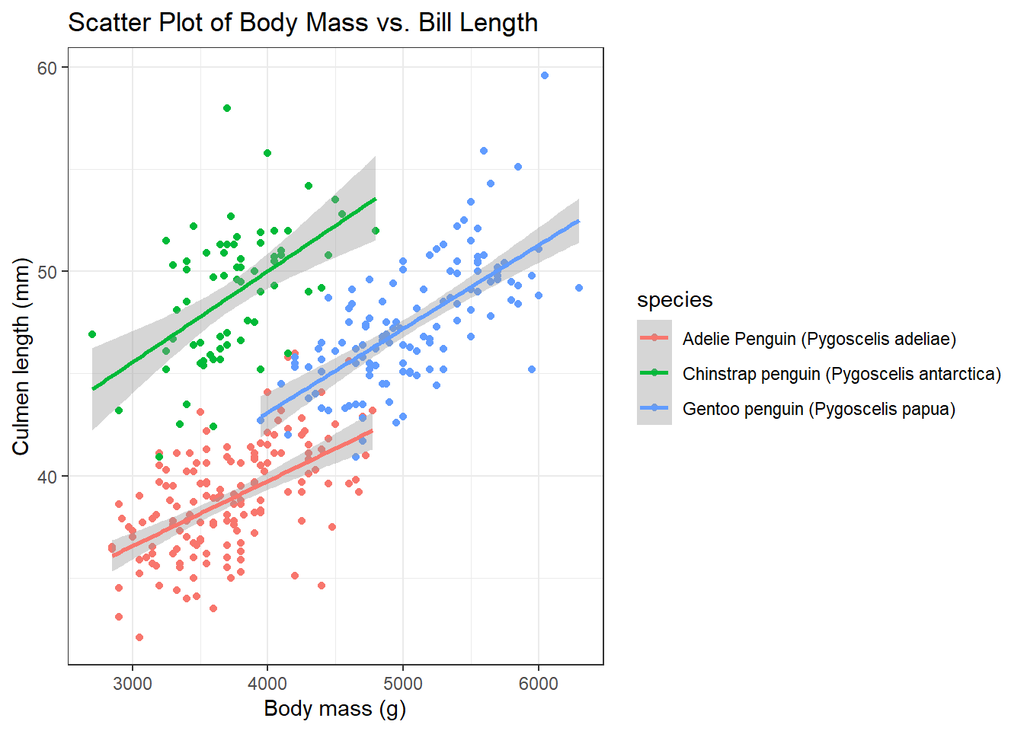

```r
penplot <- ggplot(penguins_clean, aes(x = body_mass_g , y = culmen_length_mm, colour = species)) +
  geom_point() +
  geom_smooth(method = "lm") +
    labs(x = 'Body mass (g)',
      y = 'Culmen length (mm)',
      title = "Scatter Plot of Body Mass vs. Bill Length") +
  theme_bw()
penplot
```

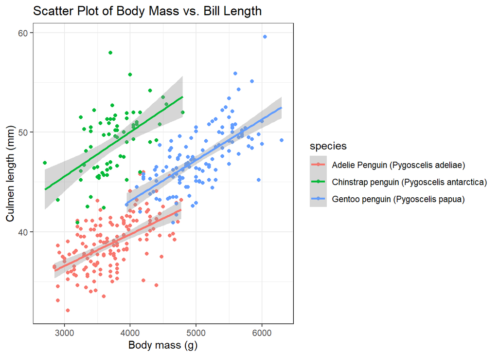

```r
penguinmodel <- plot_model_figure(penguins_clean)
penguinmodel
```

```r
save_model_plot_png(penguins_clean,
                      "figures/fig01_penguinmodel.png",
                      size = 15, res = 600, scaling=1)
```

```r
# Make sure your code prints.
```

## QUESTION 3: Open Science

### a) GitHub

*Upload your RProject you created for **Question 2** and any files and subfolders used to GitHub. Do not include any identifiers such as your name. Make sure your GitHub repo is public.*

*GitHub link:* https://github.com/1434453/Reproducible-science

*You will be marked on your repo organisation and readability.*

### b) Share your repo with a partner, download, and try to run their data pipeline.

*Partner’s GitHub link:* https://github.com/1415756/Reproducible_R

*You **must** provide this so I can verify there is no plagiarism between you and your partner.*

### c) Reflect on your experience running their code. (300-500 words)

- *What elements of your partner’s code helped you to understand their data pipeline?* It was helpful to have the comments within the sections of code explaining what each line was doing.
- *Did it run? Did you need to fix anything?* At the start I needed to create working directory with their r-markdown file, functions folder, and data folder within to make the code run. Otherwise you could not access the data and the functions. Once this was done the pipeline worked, it ran without any issues and nothing needed to be fixed.
- *What suggestions would you make for improving their code to make it more understandable or reproducible, and why?* Explain below the code chuncks what the aim of them is to do rather than putting within the code. When explanation is put within the code then it can make the code a little harder to read and therefore the whole document a little less understandable when first reading. They could have also loaded all of the packages at the beginning of the code, this would make more sense than to just load them when needed. As it would make the code flow better. Logical order to the code. They also filtered some of the data within the statistical methods section, as this is not a statistical method but a pre-requiste to a statisitical method I think it would make more sense to be included in the section previously.
- *If you needed to alter your partner’s figure using their code, do you think that would be easy or difficult, and why?* I think it would be easy as the code for the figures are laid out in the code chunks and have their own title. Therefore as it would be easy to find which section of code the graph you wanted to alter was in and thus easier to change the code.

### d) Reflect on your own code based on your experience with your partner’s code and their review of yours. (300-500 words)

- *What improvements did they suggest, and do you agree?* It was suggested that I include more details about what I am doing within the code chunks on my r-markdown file. This would include commenting line by line explaining what the code does so it is easier to read and assess. I agree with this improvement as I believe it would make sense to include a short description so it is clear what explanation aligns with a specific peice of code. However, I believe that these comments should be short as to not overcrowd the code and make it less easy to read. It was also suggested that there should be more detailed explanations when describing the statistics of the model. This includes referring clearly back to the hypothesis. Alongside this, it was also recommended that I split the single hypotheses into multiple different hypotheses as this would make it easier to test the hypotheses when multiple metrics such as significance of the slope and significance of the intercept were used.
- *What did you learn about writing code for other people?* I learnt that it is very important to explain each step in as much depth as possible so it is easier for the person reading the code to be able to understand what your intention is within each chunk. As well as making it easier to figure out what every line of code means, this would be especially helpful if you had never used the code that they have used before.